# Bank Client Data Exploration Markdown

# 3 Code Chunk 3: Exploring factor variables(Contingency Table & Group Barplot)

```r
# "housing", "loan", "poutcome" variables are selected to answer this question

# 3.A

# y and housing contingency table
data %>% select(y, housing) %>% table()
```

```
##      housing
## y       no unknown  yes
##   no  2078     118 2444
##   yes 2026     107 2507
```

```r
data %>% select(y, housing) %>% table() %>% prop.table() %>% round(4) * 100
```

```
##      housing
## y        no unknown   yes
##   no  22.39    1.27 26.34
##   yes 21.83    1.15 27.02
```

```r
# y and loan contingency table
data %>% select(y, loan) %>% table()
```

```
##      loan
## y       no unknown  yes
##   no  3838     118  684
##   yes 3850     107  683
```

```r
data %>% select(y, loan) %>% table() %>% prop.table() %>% round(4) * 100
```

```
##      loan
## y        no unknown   yes
##   no  41.36    1.27  7.37
##   yes 41.49    1.15  7.36
```

```r
# y and poutcome contingency table
data %>% select(y, poutcome) %>% table()
```

```
##      poutcome
## y     failure nonexistent success
##   no      469        4103      68
##   yes     605        3141     894
```

```r
data %>% select(y, poutcome) %>% table() %>% prop.table() %>% round(4) * 100
```

```
##      poutcome
## y     failure nonexistent success
##   no     5.05       44.21    0.73
##   yes    6.52       33.85    9.63
```

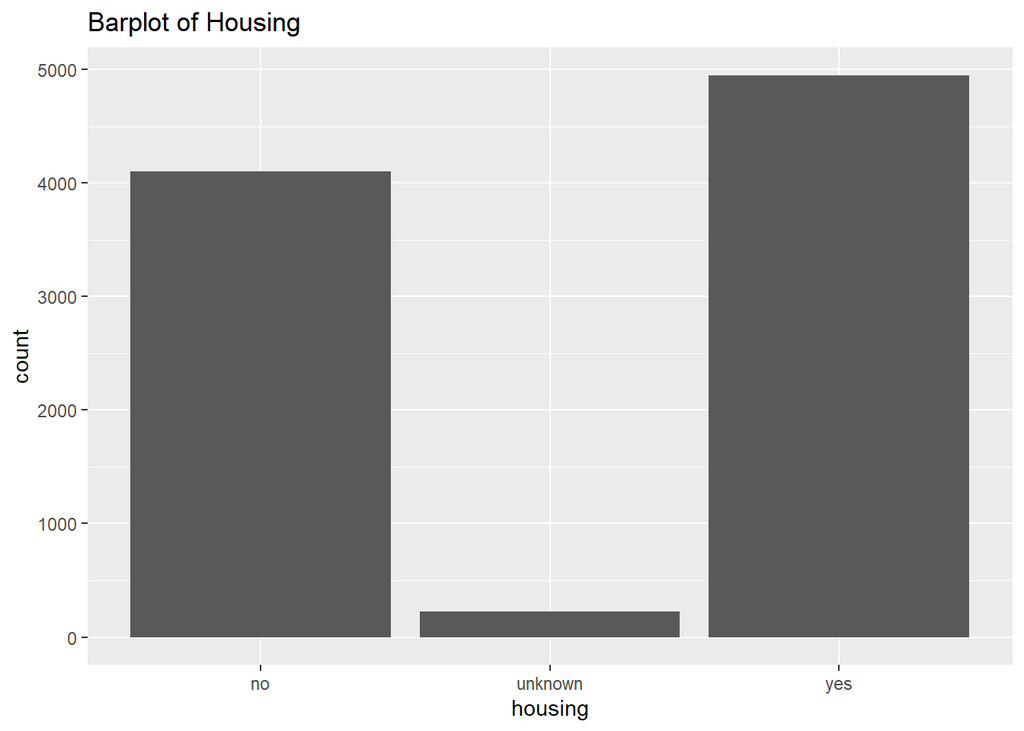

```r
# 3.B

#Barplot for Housing
data %>% ggplot()+
  geom_bar(aes(x= housing))+
  ggtitle("Barplot of Housing")
```

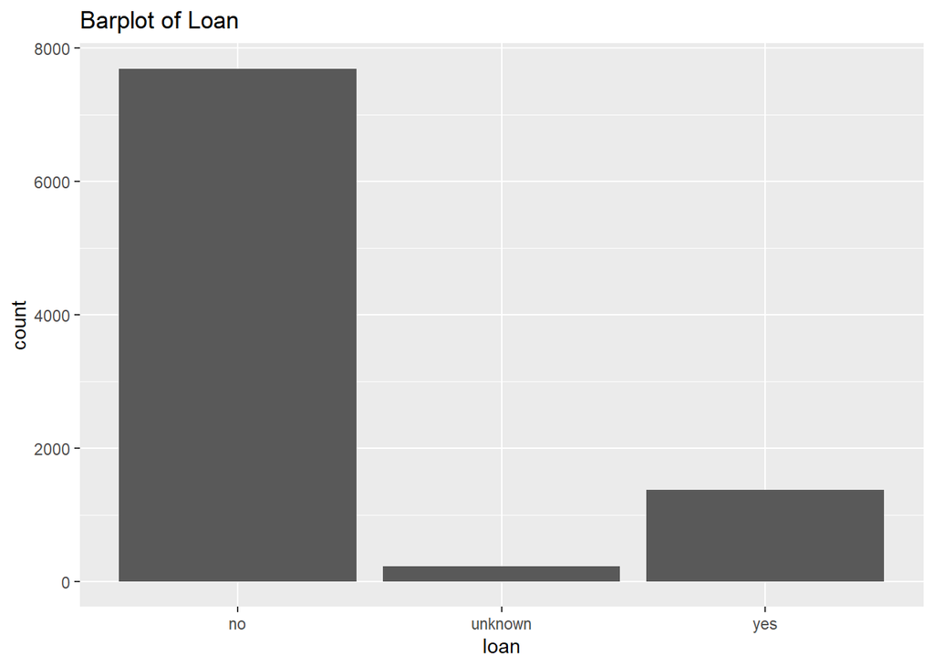

```r
#Barplot for loan
data %>% ggplot()+
  geom_bar(aes(x= loan))+
  ggtitle("Barplot of Loan")
```

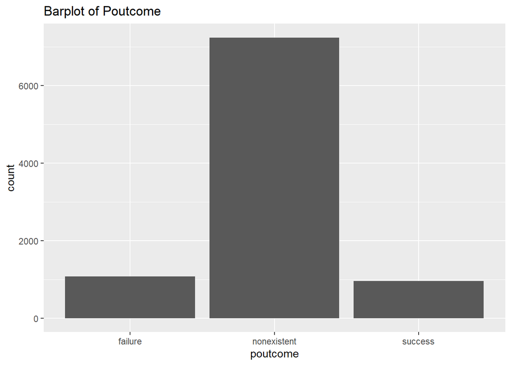

```r
#Barplot for poutcome
data %>% ggplot()+
  geom_bar(aes(x= poutcome))+
  ggtitle("Barplot of Poutcome")
```

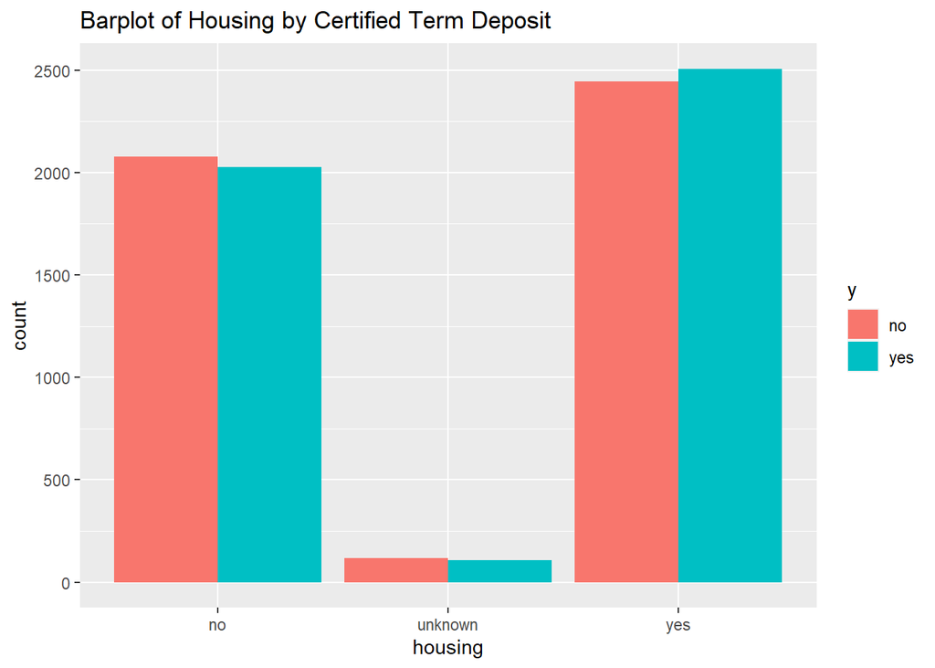

```r
# Housing by Certified Term Deposit Barplot

data %>% ggplot() +
  geom_bar(aes(x=housing,fill=y),position="dodge") +
  ggtitle("Barplot of Housing by Certified Term Deposit")
```

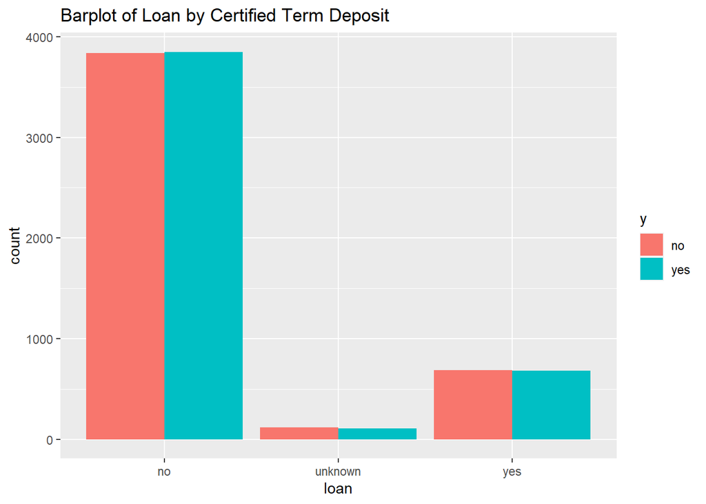

```r
# Loan by Certified Term Deposit Barplot

data %>% ggplot() +
  geom_bar(aes(x=loan,fill=y),position="dodge") +
  ggtitle("Barplot of Loan by Certified Term Deposit")
```

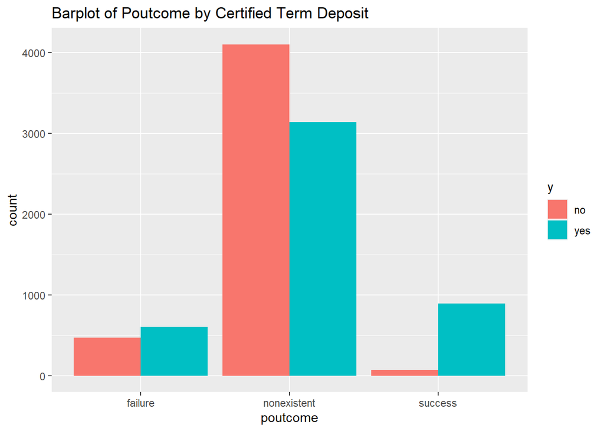

```r
# Poutcome by Certified Term Deposit Barplot

data %>% ggplot() +
  geom_bar(aes(x=poutcome,fill=y),position="dodge") +
  ggtitle("Barplot of Poutcome by Certified Term Deposit")
```

## 3.1 Bank client data Exploratory Data Analysis (Factor Variables)

- Contingency tables of counts and percentages for y (has the client subscribed a certificate term deposit) and (housing loan, personal loan, outcome of the previous marketing campaign) have been prepared.
- From the contingency tables & Barplot:
  1. It can be observed that percentage of clients with a housing loan and subscribed a certificate term deposit is higher than the percentage of people who do not have a a housing loan and do not subscribed a certificate term deposit. However, within the group of clients who have a housing loan there is almost no difference who subscribed a certificate term deposit or not. Barplot of housing loan suggests that there are more clients having a housing loan.
  2. It can be observed that percentage of clients with no personal loan and subscribed a certificate term deposit is higher than the percentage of clients with a personal loan and subscribed a certificate term deposit. However, withing the group of clients who do not have a personal loan there is almost no difference who subscribed a certificate term deposit or not. Barplot of personal loan suggests that there are few clients having a personal loan.
  3. It can be observed that the percentage of clients with previous marketing campaign success and subscribed a certificate term deposit is higher than the percentage of clients who have a failure status from the last campaign and did not subscribe a certificate term deposit. Also, clients with a success status from the last campaign all most all of them subscribed a certificate term deposit. So, poutcome is a strong predictor of who subscribed a certificate term deposit or not. Barplot of poutcome suggests that there are more failures than successes in the previous marketing campaign.

# 4 Code Chunk 4: Relationship Amongst Variables

```r
# 4.A

# Correlation among variables
data %>% select(age,duration, campaign, pdays, euribor3m, emp.var.rate, nr.employed) %>% cor()
```

```
##                       age    duration     campaign       pdays   euribor3m
## age           1.000000000 -0.02072651  0.003690016 -0.05351616 -0.04462745
## duration     -0.020726510  1.00000000 -0.025872465  0.02893622  0.05733951
## campaign      0.003690016 -0.02587247  1.000000000  0.08930062  0.17512283
## pdays        -0.053516156  0.02893622  0.089300624  1.00000000  0.38773934
## euribor3m    -0.044627449  0.05733951  0.175122827  0.38773934  1.00000000
## emp.var.rate -0.049052629  0.07144035  0.185736186  0.33488799  0.95840218
## nr.employed  -0.074686516  0.05823209  0.176972215  0.47499217  0.94054583
##              emp.var.rate nr.employed
## age           -0.04905263 -0.07468652
## duration       0.07144035  0.05823209
## campaign       0.18573619  0.17697221
## pdays          0.33488799  0.47499217
## euribor3m      0.95840218  0.94054583
## emp.var.rate   1.00000000  0.86752989
## nr.employed    0.86752989  1.00000000
```

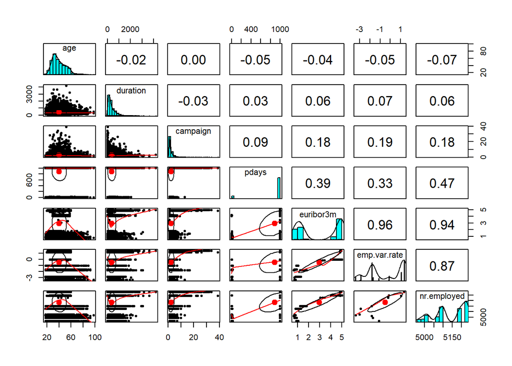

```r
#Correlation and correlation plot among variables
data %>% select(age,duration, campaign, pdays, euribor3m, emp.var.rate, nr.employed) %>% pairs.panels()
```

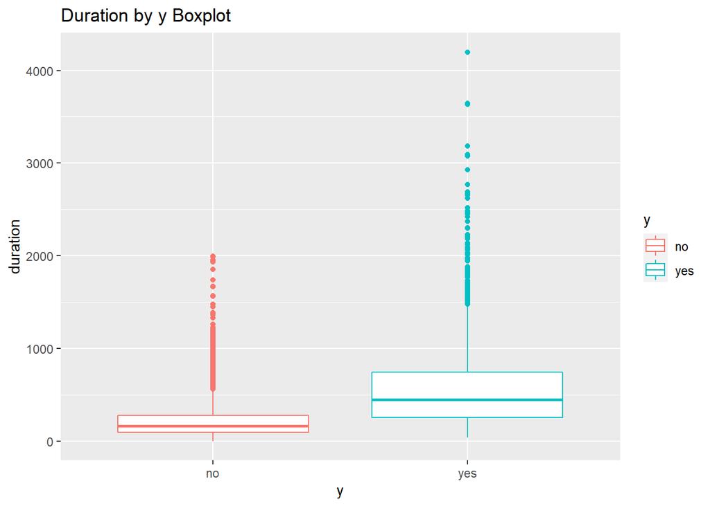

```r
# 4.B.i

# duration by y boxplot

data %>%
  ggplot() +
  geom_boxplot(aes(x=y,y=duration,color=y)) +
  ggtitle('Duration by y Boxplot')
```

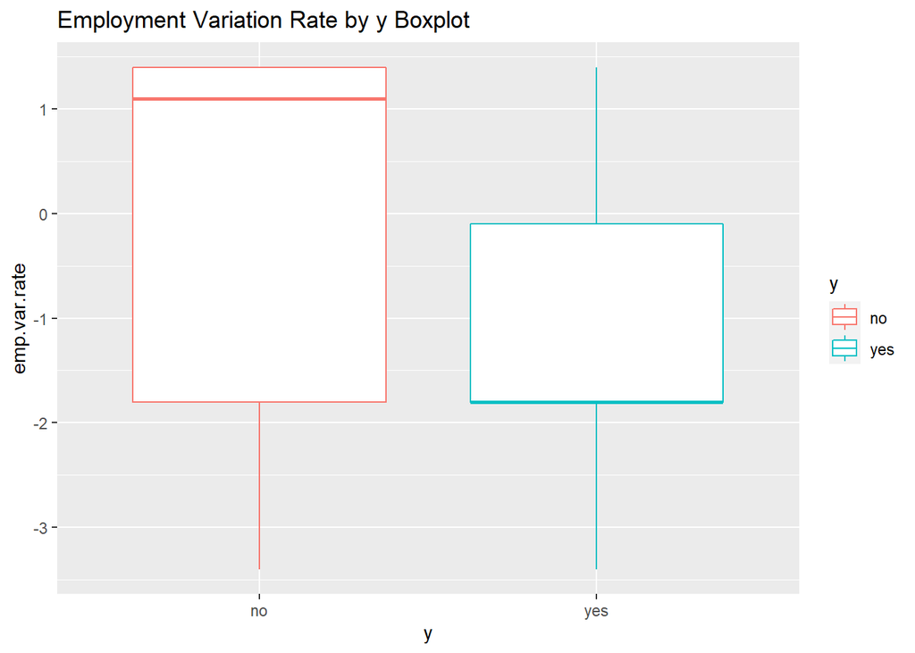

```r
# emp.var.rate by y boxplot

data %>%
  ggplot() +
  geom_boxplot(aes(x=y,y=emp.var.rate,color=y)) +
  ggtitle('Employment Variation Rate by y Boxplot')
```

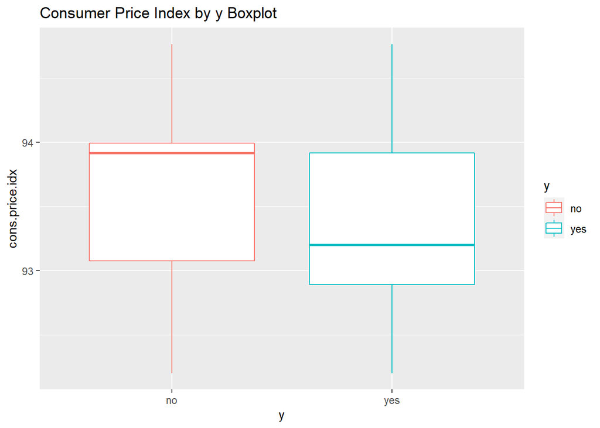

```r
# cons.price.idx by y boxplot

data %>%
  ggplot() +
  geom_boxplot(aes(x=y,y=cons.price.idx,color=y)) +
  ggtitle('Consumer Price Index by y Boxplot')
```

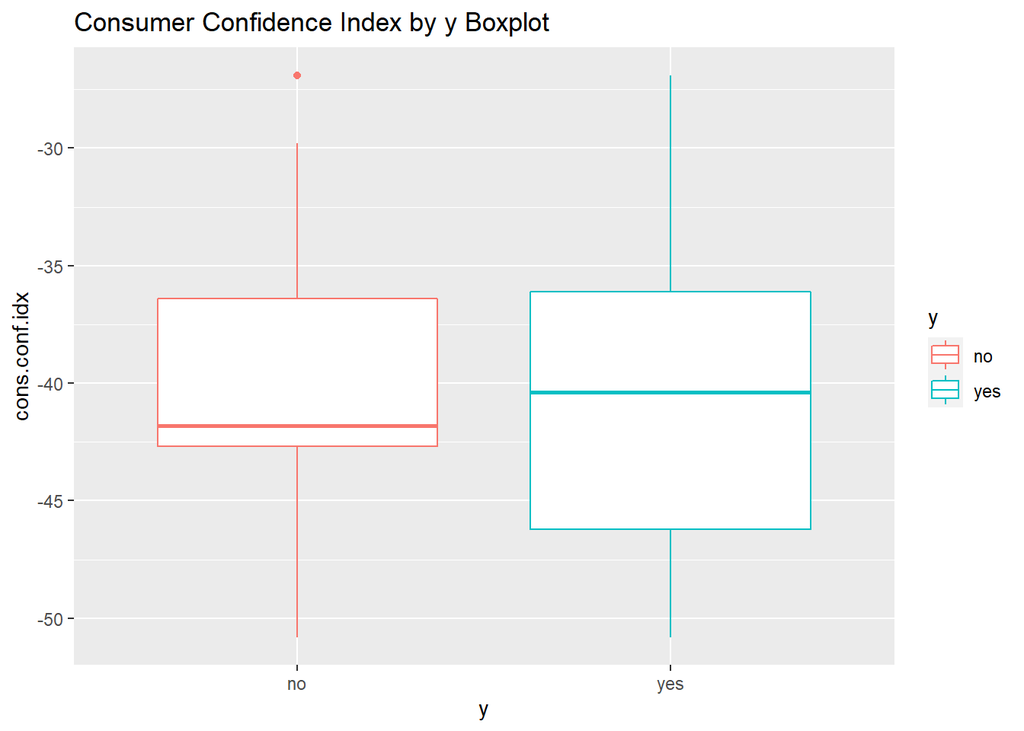

```r
# cons.conf.idx by y boxplot
data %>%
  ggplot() +
  geom_boxplot(aes(x=y,y=cons.conf.idx,color=y)) +
  ggtitle('Consumer Confidence Index by y Boxplot')
```

```r
# 4.B.ii

# Aggregate of duration by y

aggregate(duration~y, summary, data = data)
```

```
##     y duration.Min. duration.1st Qu. duration.Median duration.Mean
## 1  no        1.0000          94.0000        166.0000      221.5323
## 2 yes       37.0000         253.0000        449.0000      553.1912
##   duration.3rd Qu. duration.Max.
## 1         279.2500     1994.0000
## 2         741.2500     4199.0000
```

```r
# Aggregate of emp.var.rate by y

aggregate(emp.var.rate~y, summary, data = data)
```

```
##     y emp.var.rate.Min. emp.var.rate.1st Qu. emp.var.rate.Median
## 1  no        -3.4000000           -1.8000000           1.1000000
## 2 yes        -3.4000000           -1.8000000          -1.8000000
##   emp.var.rate.Mean emp.var.rate.3rd Qu. emp.var.rate.Max.
## 1         0.2409052            1.4000000         1.4000000
## 2        -1.2334483           -0.1000000         1.4000000
```

```r
# Aggregate of cons.price.idx by y

aggregate(cons.price.idx~y, summary, data = data)
```

```
##     y cons.price.idx.Min. cons.price.idx.1st Qu. cons.price.idx.Median
## 1  no            92.20100               93.07500              93.91800
## 2 yes            92.20100               92.89300              93.20000
##   cons.price.idx.Mean cons.price.idx.3rd Qu. cons.price.idx.Max.
## 1            93.60397               93.99400            94.76700
## 2            93.35439               93.91800            94.76700
```

```r
# Aggregate of cons.conf.idx by y

aggregate(cons.conf.idx~y, summary, data = data)
```

```
##     y cons.conf.idx.Min. cons.conf.idx.1st Qu. cons.conf.idx.Median
## 1  no          -50.80000             -42.70000            -41.80000
## 2 yes          -50.80000             -46.20000            -40.40000
##   cons.conf.idx.Mean cons.conf.idx.3rd Qu. cons.conf.idx.Max.
## 1          -40.64647             -36.40000          -26.90000
## 2          -39.78978             -36.10000          -26.90000
```